# Examples

This vignette contains example use cases for `taxonbridge`:

## Table of contents

**1. Detecting ambiguity and inconsistencies**

**2. Annotating a custom taxonomy**

**3. Visualizing a custom taxonomy**

**4. Retrieving information for a list of non-specific scientific names**

## 1. Detecting ambiguity and inconsistencies

The first example illustrates how to detect ambiguity and inconsistency in a merged taxonomy. Start by loading the 2000 row sample dataset that comes with `taxonbridge`:

```r
library(taxonbridge)
sample <- load_sample()
dim(sample)
```

```
#> [1] 2000   29
```

Next, retrieve all rows that have lineage information in both the GBIF backbone and NCBI:

```r
lineages <- get_lineages(sample)
```

Then validate the lineages by using the kingdom and family taxonomic ranks, and create a list of the resulting tibble(s). Note that phylum, class, and order may also be used. In this example, entries that failed validation are returned by setting `valid = FALSE`.

```r
kingdom <- get_validity(lineages, rank = "kingdom", valid = FALSE)
```

```
#> Term conversion carried out on kingdom taxonomic rank
```

```r
family <- get_validity(lineages, rank = "family", valid = FALSE)
candidates <- list(kingdom, family)
```

Finally, detect candidate incongruencies (excluding those with uninomial scientific names):

```r
get_inconsistencies(candidates, uninomials = FALSE)
```

```
#> [1] "Gordonia neofelifaecis"  "Attheya septentrionalis"
```

Two binomial names exhibit incongruency. Upon reference to the literature and the individual entries it can be seen that:

- *Attheya septentrionalis* is assigned to different families of the **problematica** order Chaetocerotales
- *Gordonia neofelifaecis* is a plant (family: Theaceae) in the GBIF but a bacterium in the NCBI (family: Gordoniaceae)

*Attheya septentrionalis* has the status “synonym” in the GBIF data:

```r
lineages[lineages$canonicalName=="Attheya septentrionalis", "taxonomicStatus"]
```

```
#> # A tibble: 1 × 1
#>   taxonomicStatus
#>   <chr>
#> 1 synonym
```

Applying the `get_status()` function and rerunning the exercise leaves only *Gordonia neofelifaecis* as a binomial incongruency with biological provenance:

```r
lineages <- get_status(get_lineages(sample), status = "accepted")
kingdom <- get_validity(lineages, rank = "kingdom", valid = FALSE)
```

```
#> Term conversion carried out on kingdom taxonomic rank
```

```r
family <- get_validity(lineages, rank = "family", valid = FALSE)
candidates <- list(kingdom, family)
get_inconsistencies(candidates, uninomials = FALSE)
```

```
#> [1] "Gordonia neofelifaecis"
```

## 2. Annotating a custom taxonomy

Again, start by loading the 2000 row sample dataset that comes with `taxonbridge`. Then apply the `get_taxa()` method to find all decapod crustaceans in the sample dataset:

```r
library(taxonbridge)
sample <- load_sample()
decapoda <- get_taxa(sample, order = "decapoda")
```

The `decapoda` object will serve as your base taxonomy. Create a new object that only retains decapods known as swimming crabs:

```r
swimming_crabs <- get_taxa(sample, family = "portunidae")
```

Next annotate your base taxonomy with this colloquial name for the family Portunidae:

```r
decapoda <- annotate(decapoda, names = swimming_crabs$canonicalName,
                     new_column = "swimming_crabs", present = "1")
```

A new column by the name “swimming_crabs” has been added to the base taxonomy:

```r
colnames(decapoda)
```

```
#>  [1] "taxonID"              "canonicalName"        "taxonRank"
#>  [4] "parentNameUsageID"    "acceptedNameUsageID"  "originalNameUsageID"
#>  [7] "taxonomicStatus"      "kingdom"              "phylum"
#> [10] "class"                "order"                "family"
#> [13] "genericName"          "specificEpithet"      "infraspecificEpithet"
#> [16] "ncbi_id"              "ncbi_lineage_names"   "ncbi_lineage_ids"
#> [19] "ncbi_rank"            "ncbi_lineage_ranks"   "from_GBIF"
#> [22] "ncbi_kingdom"         "ncbi_phylum"          "ncbi_class"
#> [25] "ncbi_order"           "ncbi_family"          "ncbi_genus"
#> [28] "ncbi_species"         "from_NCBI"            "swimming_crabs"
```

Since only the `present` parameter and not the `absent` parameter was passed to `annotate()`, all species that are not members of the Portunidae will be assigned `NA` by default in the `swimming_crabs` column. Swimming crabs can therefore be retrieved from the base taxonomy with the following command:

```r
decapoda[!is.na(decapoda$swimming_crabs),"canonicalName"]
```

```
#> # A tibble: 1 × 1
#>   canonicalName
#>   <chr>
#> 1 Callinectes sapidus
```

## 3. Visualizing a custom taxonomy

Continue using the annotated base taxonomy from example 2. Prepare two distributions for the base taxonomy using `prepare_rank_dist()`:

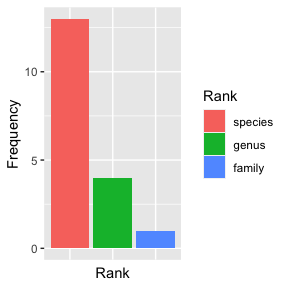

```r
GBIF_dist <- prepare_rank_dist(decapoda, GBIF = TRUE)
NCBI_dist <- prepare_rank_dist(decapoda, NCBI = TRUE)
plot_mdb(GBIF_dist)
plot_mdb(NCBI_dist)
```

[output not shown]

```r
GBIF_dist
```

```
#> $GBIF
#> # A tibble: 3 × 2
#>   Rank    Frequency
#>   <chr>       <int>
#> 1 family          1
#> 2 genus           4
#> 3 species        13
#>
#> attr(,"class")
#> [1] "one_rank"
```

```r
NCBI_dist
```

```
#> $NCBI
#> # A tibble: 4 × 2
#>   Rank    Frequency
#>   <chr>       <int>
#> 1 family          1
#> 2 genus           4
#> 3 species        11
#> 4 <NA>            2
#>
#> attr(,"class")
#> [1] "one_rank"
```

Assuring that both the NCBI data and GBIF data have lineage data by using `get_lineages()` solves this problem at the cost of losing two GBIF entries that are not available in the NCBI:

```r
lineages <- get_lineages(decapoda)
GBIF_dist <- prepare_rank_dist(lineages, GBIF = TRUE)
NCBI_dist <- prepare_rank_dist(lineages, NCBI = TRUE)
plot_mdb(GBIF_dist)
plot_mdb(NCBI_dist)
```

Note that `get_lineages()` should be used with care since extinct species in the GBIF are unlikely to have lineage data in the NCBI.

Now that both the GBIF and NCBI data have lineage information, the validity of the lineage information can be accessed in the same way as was done in example 1:

```r
get_validity(lineages, valid = FALSE)
```

```
#> # A tibble: 3 × 30
#>    taxonID canonicalName         taxonRank parentNameUsageID acceptedNameUsageID
#>      <dbl> <chr>                 <chr>                 <dbl>               <dbl>
#> 1 11343777 Orithyia              genus                  6316             2117279
#> 2  2221665 Palibythus magnificus species             2221664                  NA
#> 3  2226015 Lysirude              genus               6927319                  NA
#> # … with 25 more variables: originalNameUsageID <dbl>, taxonomicStatus <chr>,
#> #   kingdom <chr>, phylum <chr>, class <chr>, order <chr>, family <chr>,
#> #   genericName <chr>, specificEpithet <chr>, infraspecificEpithet <chr>,
#> #   ncbi_id <dbl>, ncbi_lineage_names <chr>, ncbi_lineage_ids <chr>,
#> #   ncbi_rank <chr>, ncbi_lineage_ranks <chr>, from_GBIF <dbl>,
#> #   ncbi_kingdom <chr>, ncbi_phylum <chr>, ncbi_class <chr>, ncbi_order <chr>,
#> #   ncbi_family <chr>, ncbi_genus <chr>, ncbi_species <chr>, from_NCBI <dbl>, …
```

Three entries have invalid data:

- The genus *Orithyia* belongs to the family Phoxichilidiidae in the GBIF but belongs to the family Orithyiidae in the NCBI.
- The species *Palibythus magnificus* belongs to the family Palinuridae in the GBIF but belongs to the family Synaxidae in the NCBI.
- The genus *Lysirude* belongs to the family Lyreididae in the GBIF but belongs to the family Raninidae in the NCBI.

Annotating the base taxonomy with these inconsistencies is a good idea:

```r
decapoda <- annotate(decapoda, get_validity(lineages, valid = FALSE)$canonicalName,
                    new_column = "family_inconsistencies", present = 1)
```

```
#> 3 annotations were made.
```

```r
colnames(decapoda)
```

```
#>  [1] "taxonID"                "canonicalName"          "taxonRank"
#>  [4] "parentNameUsageID"      "acceptedNameUsageID"    "originalNameUsageID"
#>  [7] "taxonomicStatus"        "kingdom"                "phylum"
#> [10] "class"                  "order"                  "family"
#> [13] "genericName"            "specificEpithet"        "infraspecificEpithet"
#> [16] "ncbi_id"                "ncbi_lineage_names"     "ncbi_lineage_ids"
#> [19] "ncbi_rank"              "ncbi_lineage_ranks"     "from_GBIF"
#> [22] "ncbi_kingdom"           "ncbi_phylum"            "ncbi_class"
#> [25] "ncbi_order"             "ncbi_family"            "ncbi_genus"
#> [28] "ncbi_species"           "from_NCBI"              "swimming_crabs"
#> [31] "family_inconsistencies"
```

```r
decapoda[!is.na(decapoda$family_inconsistencies),"canonicalName"]
```

```
#> # A tibble: 3 × 1
#>   canonicalName
#>   <chr>
#> 1 Orithyia
#> 2 Palibythus magnificus
#> 3 Lysirude
```

## 4. Retrieving information for a list of non-specific scientific names

In this example a researcher is in possession of a list of scientific names of cone snails. The researcher has a three-fold concern. Firstly, some names in the list are non-specific since the researcher would like to include all species in a genus (e.g., “genus sp”). Secondly, the researcher is aware that there are changes in the taxonomic status of cone snails from time to time and would like to detect new or changed taxonomic entries. Lastly, the researcher would like to retrieve the associated GBIF and NCBI identifiers for all entries as well as the taxonomic status of every entry.

NOTE: The following script requires [Taxonkit](https://bioinf.shenwei.me/taxonkit/download/) and may take some time to complete execution.

```r
library(taxonbridge)

#Retrieve and merge NCBI and GBIF data. INSERT PATH TO YOUR TAXONKIT INSTALLATION.
custom_taxonomy <- load_taxonomies(download_gbif(),
                                   download_ncbi(taxonkitpath = "/path/to/taxonkit"))

#Create a custom taxonomy of all gastropods
custom_taxonomy <- get_taxa(custom_taxonomy, class = "gastropoda")
remove(dt)

#Use fuzzy_search to find occurrences of the names within the custom taxonomy
search_result <- c()
sp_names <- c("Natica sp", "Conus sp")
for (i in sp_names) {
  iter <- fuzzy_search(custom_taxonomy, i, allow_term_removal = TRUE)
  search_result <- c(search_result, iter)
}
exact_names <- c("Polinices mammillata", "Cymatium pileare",
                 "Chicoreus ramosus", "Murex tenuirostris","Vasum turbinellum",
                 "Oliva amethystina", "Mitra mitra", "Nassa serta",
                 "Phos senticosus")
for (i in exact_names) {
  iter <- fuzzy_search(custom_taxonomy, i, allow_term_removal = FALSE)
  search_result <- c(search_result, iter)
}

#Annotate the custom taxonomy
custom_taxonomy <- annotate(custom_taxonomy, names = search_result, new_column = "cone_snails")

#Filter on the annotation
custom_taxonomy <- custom_taxonomy[!is.na(custom_taxonomy$cone_snails),]

#De-duplicate the custom taxonomy
custom_taxonomy <- dedupe(custom_taxonomy, ranked = TRUE)

#Create a subset of relevant data
custom_taxonomy_short <- custom_taxonomy[, c(1,17,2,3,20,7)]
colnames(custom_taxonomy_short) <- c("GBIF_id", "NCBI_id", "species_name",
                                     "GBIF_rank", "NCBI_rank", "taxonomic_status")

#Print the results to the terminal
print(custom_taxonomy_short, n=100)
```